# Practical Machine Learning Course Project

Suparna Sen

June 14, 2016

## Background

Using devices such as Jawbone Up, Nike FuelBand, and Fitbit it is now possible to collect a large amount of data about personal activity relatively inexpensively. These type of devices are part of the quantified self movement - a group of enthusiasts who take measurements about themselves regularly to improve their health, to find patterns in their behavior, or because they are tech geeks. One thing that people regularly do is quantify how much of a particular activity they do, but they rarely quantify how well they do it. In this project, your goal will be to use data from accelerometers on the belt, forearm, arm, and dumbell of 6 participants. They were asked to perform barbell lifts correctly and incorrectly in 5 different ways. More information is available from the website here: http://groupware.les.inf.puc-rio.br/har (see the section on the Weight Lifting Exercise Dataset).

### Data

The training data for this project are available here: https://d396qusza40orc.cloudfront.net/predmachlearn/pml-training.csv The test data are available here: https://d396qusza40orc.cloudfront.net/predmachlearn/pml-testing.csv The data for this project come from this source: http://groupware.les.inf.puc-rio.br/har. If you use the document you create for this class for any purpose please cite them as they have been very generous in allowing their data to be used for this kind of assignment.

### Goal

The goal of your project is to predict the manner in which they did the exercise. This is the “classe” variable in the training set. You may use any of the other variables to predict with. You should create a report describing how you built your model, how you used cross validation, what you think the expected out of sample error is, and why you made the choices you did. You will also use your prediction model to predict 20 different test cases.

## Loading Required Packages

```r
library(caret)
```

```r
library(rpart)
library(rpart.plot)
library(RColorBrewer)
library(rattle)
library(randomForest)
library(corrplot)
```

### Set seed for reproducibility

```r
set.seed(12345)
```

### Getting & Loading data

```r
trainUrl <- "http://d396qusza40orc.cloudfront.net/predmachlearn/pml-training.csv"
testUrl <- "http://d396qusza40orc.cloudfront.net/predmachlearn/pml-testing.csv"

training <- read.csv(url(trainUrl), na.strings=c("NA","#DIV/0!",""))
testing <- read.csv(url(testUrl), na.strings=c("NA","#DIV/0!",""))
dim(training); dim(testing)
```

```
## [1] 19622   160
```

```
## [1]  20 160
```

```r
trainingCols<-colnames(training)
testingCols<-colnames(testing)
```

## Data Processing

```r
# Verify variable names in traing and test set (excluding classe and problem_id)
all.equal(trainingCols[1:length(trainingCols)-1], testingCols[1:length(testingCols)-1])
```

```
## [1] TRUE
```

```r
# Eliminating variables with mostly NA
NAS<- sapply(training, function(x) mean(is.na(x))) > 0.95
training <- training[, NAS==FALSE]
testing  <- testing[, NAS==FALSE]
dim(training); dim(testing)
```

```
## [1] 19622    60
```

```
## [1] 20 60
```

```r
# Delete some extraneous/ irrelevant variables (1 to 7) : X, user_name, raw_timestamp_part_1, raw_timestamp_part_,2 cvtd_timestamp, new_window, num_window
training  <- training[, -c(1:7)]
testing   <- testing[, -c(1:7)]
dim(training); dim(testing)
```

```
## [1] 19622    53
```

```
## [1] 20 53
```

### Remove NearZeroVariance variables

```r
nzv <- nearZeroVar(training, saveMetrics=TRUE)
training <- training[,nzv$nzv==FALSE]

nzv<- nearZeroVar(testing,saveMetrics=TRUE)
testing <- testing[,nzv$nzv==FALSE]
dim(training); dim(testing)
```

```
## [1] 19622    53
```

```
## [1] 20 53
```

### Preprocessing variables

```r
v <- which(lapply(training, class) %in% "numeric")

preObj <-preProcess(training[,v],method=c('knnImpute', 'center', 'scale'))
trainPP <- predict(preObj, training[,v])
trainPP$classe <- training$classe

testPP <-predict(preObj,testing[,v])
```

### Creating cross validation set (Partitioning the Data)

The training set is divided in two parts, one for training and the other for cross validation

```r
inTrain = createDataPartition(trainPP$classe, p = 3/4, list=FALSE)
trainSet = trainPP[inTrain,]
crossValidation = trainPP[-inTrain,]
```

# The Model

The methods are: * Random Forests, * Decision Tree and * Generalized Boosted Model.

A Confusion Matrix is plotted at the end of each analysis to better visualize the accuracy of the models.

## I. Prediction with Random Forests

```r
# model fit
(random_forest=randomForest(classe~.,data=trainSet,importance=TRUE))
```

```
##
## Call:
##  randomForest(formula = classe ~ ., data = trainSet, importance = TRUE)
##                Type of random forest: classification
##                      Number of trees: 500
## No. of variables tried at each split: 5
##
##         OOB estimate of  error rate: 0.58%
## Confusion matrix:
##      A    B    C    D    E class.error
## A 4180    4    0    0    1 0.001194743
## B   12 2827    8    0    1 0.007373596
## C    0   11 2541   14    1 0.010128555
## D    0    0   15 2393    4 0.007877280
## E    1    2    3    9 2691 0.005543237
```

```r
# prediction on cross validation dataset
predictionRF <- predict(random_forest, crossValidation, type = "class")
cmRF <- confusionMatrix(predictionRF, crossValidation$classe)
cmRF
```

```
## Confusion Matrix and Statistics
##
##           Reference
## Prediction    A    B    C    D    E
##          A 1393    8    0    0    0
##          B    2  938    4    0    0
##          C    0    3  845    6    1
##          D    0    0    6  797    3
##          E    0    0    0    1  897
##
## Overall Statistics
##
##                Accuracy : 0.9931
##                  95% CI : (0.9903, 0.9952)
##     No Information Rate : 0.2845
##     P-Value [Acc > NIR] : < 2.2e-16
##
##                   Kappa : 0.9912
##  Mcnemar's Test P-Value : NA
##
## Statistics by Class:
##
##                      Class: A Class: B Class: C Class: D Class: E
## Sensitivity            0.9986   0.9884   0.9883   0.9913   0.9956
## Specificity            0.9977   0.9985   0.9975   0.9978   0.9998
## Pos Pred Value         0.9943   0.9936   0.9883   0.9888   0.9989
## Neg Pred Value         0.9994   0.9972   0.9975   0.9983   0.9990
## Prevalence             0.2845   0.1935   0.1743   0.1639   0.1837
## Detection Rate         0.2841   0.1913   0.1723   0.1625   0.1829
## Detection Prevalence   0.2857   0.1925   0.1743   0.1644   0.1831
## Balanced Accuracy      0.9981   0.9934   0.9929   0.9945   0.9977
```

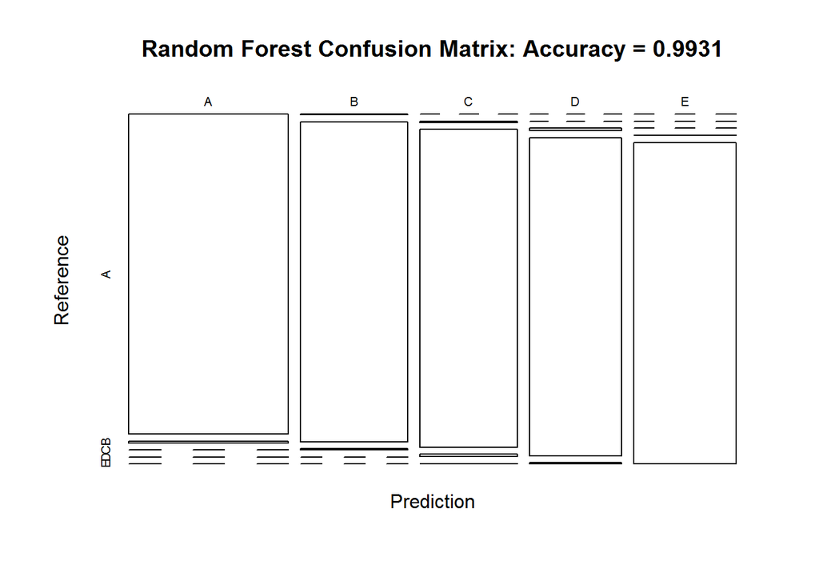

```r
# Plot Confusion Matrix
plot(cmRF$table, col = cmRF$byClass, main = paste("Random Forest Confusion Matrix: Accuracy =", round(cmRF$overall['Accuracy'], 4)))
```

## II. Prediction with Decision Tree

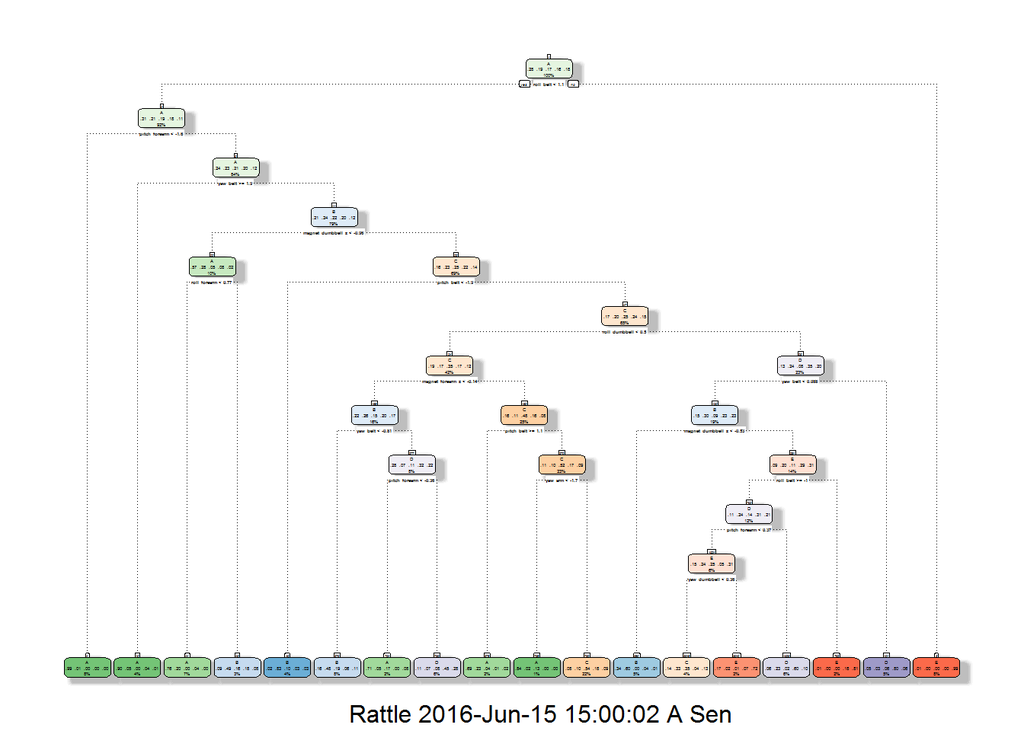

```r
# model fit
decision_tree <- rpart(classe ~ ., data=trainSet, method="class")

# Plot Decision Tree
fancyRpartPlot(decision_tree)
```

```r
# prediction on cross validation dataset
predictDT <- predict(decision_tree, newdata=crossValidation, type="class")
cmDT <- confusionMatrix(predictDT, crossValidation$classe)
cmDT
```

```
## Confusion Matrix and Statistics
##
##           Reference
## Prediction    A    B    C    D    E
##          A 1069  135   36   30   14
##          B  147  536  100   61   73
##          C   95  176  677  190  135
##          D   56   97   39  489  138
##          E   28    5    3   34  541
##
## Overall Statistics
##
##                Accuracy : 0.6754
##                  95% CI : (0.6621, 0.6885)
##     No Information Rate : 0.2845
##     P-Value [Acc > NIR] : < 2.2e-16
##
##                   Kappa : 0.591
##  Mcnemar's Test P-Value : < 2.2e-16
##
## Statistics by Class:
##
##                      Class: A Class: B Class: C Class: D Class: E
## Sensitivity            0.7663   0.5648   0.7918  0.60821   0.6004
## Specificity            0.9387   0.9037   0.8528  0.91951   0.9825
## Pos Pred Value         0.8326   0.5845   0.5318  0.59707   0.8854
## Neg Pred Value         0.9099   0.8964   0.9510  0.92289   0.9161
## Prevalence             0.2845   0.1935   0.1743  0.16395   0.1837
## Detection Rate         0.2180   0.1093   0.1381  0.09971   0.1103
## Detection Prevalence   0.2618   0.1870   0.2596  0.16701   0.1246
## Balanced Accuracy      0.8525   0.7342   0.8223  0.76386   0.7915
```

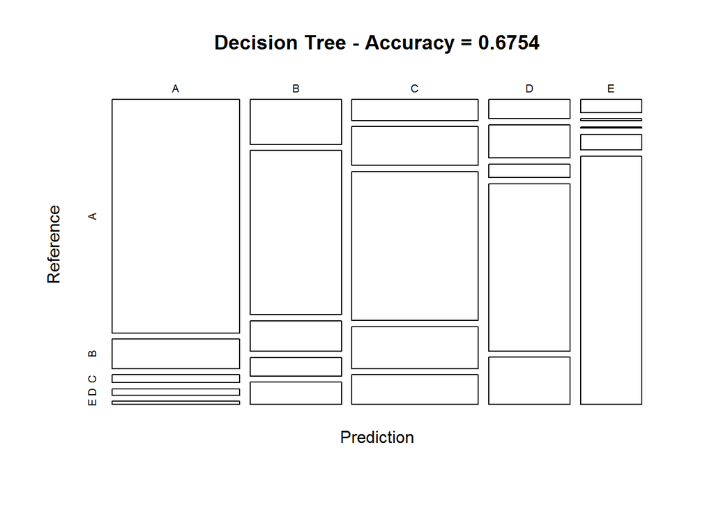

```r
# plot matrix results
plot(cmDT$table, col = cmDT$byClass,
     main = paste("Decision Tree - Accuracy =",
                  round(cmDT$overall['Accuracy'], 4)))
```

## III. Prediction with Generalized Boosted Model

```r
GBM <- trainControl(method = "repeatedcv", number = 5, repeats = 1)
modGBM  <- train(classe ~ ., data=trainSet, method = "gbm",trControl = GBM, verbose = FALSE)
modGBM$finalModel
```

```
## A gradient boosted model with multinomial loss function.
## 150 iterations were performed.
## There were 27 predictors of which 25 had non-zero influence.
```

```r
# prediction on cross validation dataset
predictGBM <- predict(modGBM, newdata=crossValidation)
cmGBM <- confusionMatrix(predictGBM, crossValidation$classe)
cmGBM
```

```
## Confusion Matrix and Statistics
##
##           Reference
## Prediction    A    B    C    D    E
##          A 1359   43    0    0    5
##          B   22  863   30    5    9
##          C   11   37  805   28   18
##          D    2    4   16  764   27
##          E    1    2    4    7  842
##
## Overall Statistics
##
##                Accuracy : 0.9447
##                  95% CI : (0.938, 0.951)
##     No Information Rate : 0.2845
##     P-Value [Acc > NIR] : < 2e-16
##
##                   Kappa : 0.9301
##  Mcnemar's Test P-Value : 1.3e-07
##
## Statistics by Class:
##
##                      Class: A Class: B Class: C Class: D Class: E
## Sensitivity            0.9742   0.9094   0.9415   0.9502   0.9345
## Specificity            0.9863   0.9833   0.9768   0.9880   0.9965
## Pos Pred Value         0.9659   0.9290   0.8954   0.9397   0.9836
## Neg Pred Value         0.9897   0.9784   0.9875   0.9902   0.9854
## Prevalence             0.2845   0.1935   0.1743   0.1639   0.1837
## Detection Rate         0.2771   0.1760   0.1642   0.1558   0.1717
## Detection Prevalence   0.2869   0.1894   0.1833   0.1658   0.1746
## Balanced Accuracy      0.9803   0.9463   0.9592   0.9691   0.9655
```

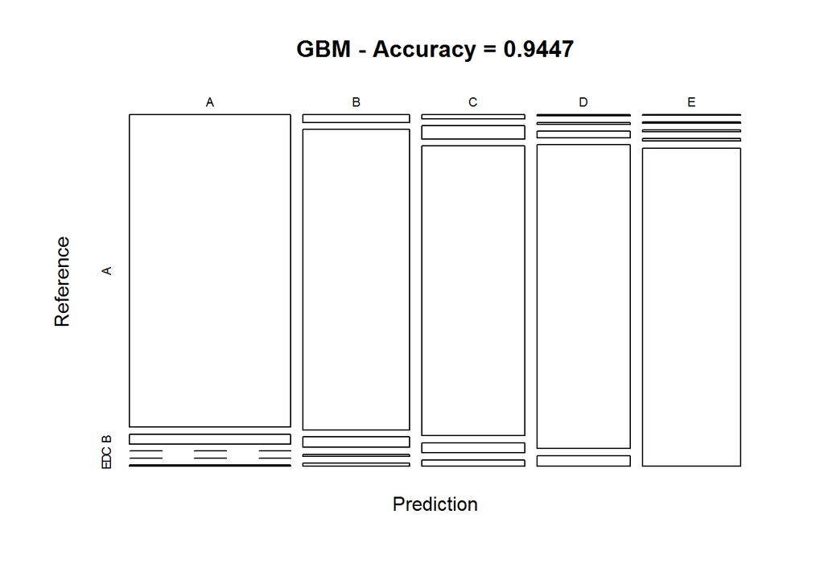

```r
# plot matrix results
plot(cmGBM$table, col = cmGBM$byClass,
     main = paste("GBM - Accuracy =", round(cmGBM$overall['Accuracy'], 4)))
```

# Selected Model & applying to the Test Data

The accuracy of the above three regression modeling methods above are: I. Random Forest : 0.9931 II. Decision Tree : 0.6754 III. GBM : 0.9447

The Random Forest model is selected to predict the 20 quiz results (testing dataset) as shown below.

```r
# model fit
(modRF=randomForest(classe~.,data=training,importance=TRUE))
```

```
##
## Call:
##  randomForest(formula = classe ~ ., data = training, importance = TRUE)
##                Type of random forest: classification
##                      Number of trees: 500
## No. of variables tried at each split: 7
##
##         OOB estimate of  error rate: 0.3%
## Confusion matrix:
##      A    B    C    D    E  class.error
## A 5578    1    0    0    1 0.0003584229
## B   12 3782    3    0    0 0.0039504872
## C    0   12 3409    1    0 0.0037989480
## D    0    0   20 3194    2 0.0068407960
## E    0    0    0    7 3600 0.0019406709
```

```r
# prediction on TEST dataset
predictionRF_FINAL <- predict(modRF, newdata=testing, type = "class")
predictionRF_FINAL
```

```
##  1  2  3  4  5  6  7  8  9 10 11 12 13 14 15 16 17 18 19 20
##  B  A  B  A  A  E  D  B  A  A  B  C  B  A  E  E  A  B  B  B
## Levels: A B C D E
```